# Lost and Found Analysis - PVAS

HASS Data

10/25/2021

This report is (usually) focused around Lost and Found data using the intakes and outcomes data received for 2019 and 2020. Its goal is to reflect everything we could learn about L&F from the available data and highlight things that would be useful to show but some/all data required for them are missing.

**In this case, only 2017-2018 data was analyzed here since it had found and home address locations for RTH animals, which is usually unavailable. If interested, other analysis can be done for the 2019-onwards data.**

### Executive Summary

1. The 2017-2018 data sent to HASS allowed to build stray intake/RTH rate maps, showing the number of stray dogs coming in and the return rate for each ZIP Code. This was not available for newer data based on what has been sent so far.
2. Of the strays who got RTO outcomes in 2017-2018 with an identifiable found and owner addresses (704 dogs), 51% were found less than a mile away from home, and half of those (25% of all dogs) were found less than a block away from home. 20% of all dogs were found more than 5 miles away.

### Distances Traveled by Lost Dogs - 2017-2018

This section uses the outcome files received for years 2017 and 2018, because they include both a found location AND an outcome address for each animal, unlike the more recent files we have (for which an outcome address was never requested, so it makes sense it is not there). These two data points mean we could find out how far away do dogs go from home when they get lost (and are found).

Across both these years, there were 848 strays who had an RTO outcome. Out of those, 764 dogs had usable addresses for both found and outcome locations, after excluding addresses that could not be easily converted to a precise location (common themes: ‘mile X of road Y’, ‘see memo’, ‘local canal’, or a missing value). For each dog, the listed intake address and owner addresses were geocoded (using Google’s geolocation service), and then the distance between the two points was calculated. Some addresses were geocoded incorrectly and were removed, as were dogs with a distance of more than 40 miles between the two points, which were few. Some of these can be corrected if needed. This filtering left a total of 704 dogs.

**Of these dogs, 51% were found less than a mile away from home, and half of those (25% of all dogs) were found less than a block away from home. 20% of all dogs were found more than 5 miles away**. The distribution of distances is shown in the following figure.

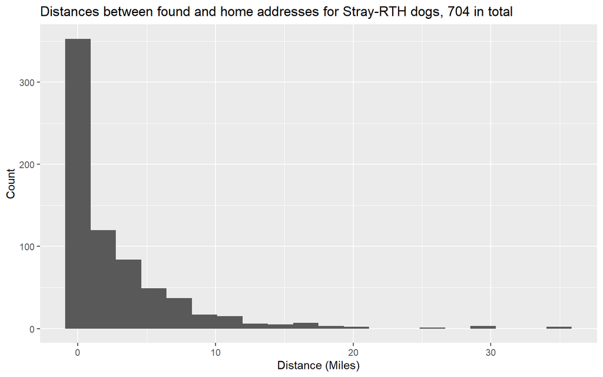

[interactive chart not shown]

### Stray Intake and RTH By Found ZIP

The following maps show stray intake and RTH rate by ZIP codes to highlight geographical patterns. The first and second tab are similar to previous metrics; the third tab, RTH Gap, shows the number of strays who were *not* returned home per ZIP code.

These maps use the 2017-2018 data because it is currently not possible to map the number of strays and rates of RTH per area in the more recent files, as there are no ZIP codes associated with each intake record. However, there is a crossing address, and we could work on cleaning these up and transforming them into a ZIP code or geolocation for mapping.

#### Stray Intakes

[interactive chart not shown]

#### RTH Rate

RTH Rate per ZIP code.

[interactive chart not shown]

#### RTH Gap

This combines the other two tabs to highlight where most additional RTH potential exists.

[interactive chart not shown]